# Supplemental Plots

## Table S1

Table S1. Input parameters for the population and fishery dynamics operating model representative of Atlantic red snapper. N/A indicates not applicable.

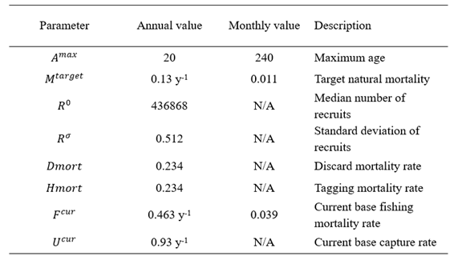

Table S1

## Table S2

Table S2. Operating model input vectors from the Atlantic red snapper stock assessment model (SEDAR 2021a) and the Florida State Reef Fish Survey (SRFS).

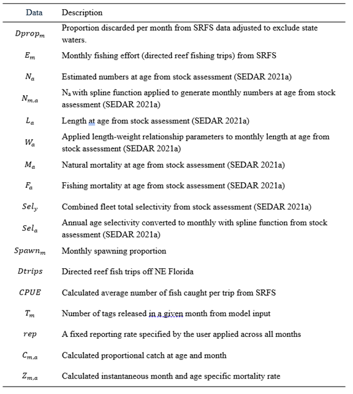

Table S2

## Table S3

Table S3. Model comparison among red snapper estimation models computed during simulation testing to estimate the CV on discard capture rate for Atlantic red snapper with 3,000 fish tagged and a 95% reporting rate. If the parameter name is preceded by a value it is fixed at that value. If it is preceded by timebin it is estimated by time bin and if by agebin it is estimated by age bin. An asterisk indicates there are fixed values within a bin.

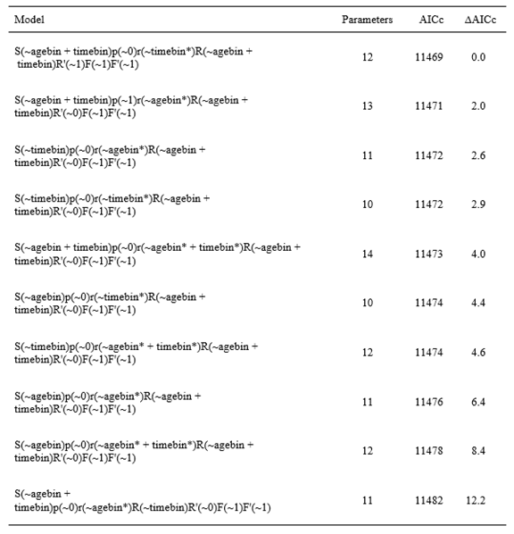

Table S3

## Figure S1

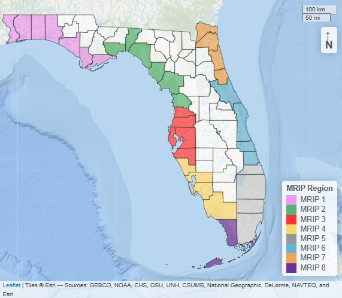

Figure S1. Map of the counties in U.S. state of Florida. The colors indicate the counties in each designated effort zone where sampling takes place for the Marine Recreational Information Program (MRIP 2025). MRIP zones 6 and 7 are representative of the northern and southern boundaries of this study.

## Figure S2

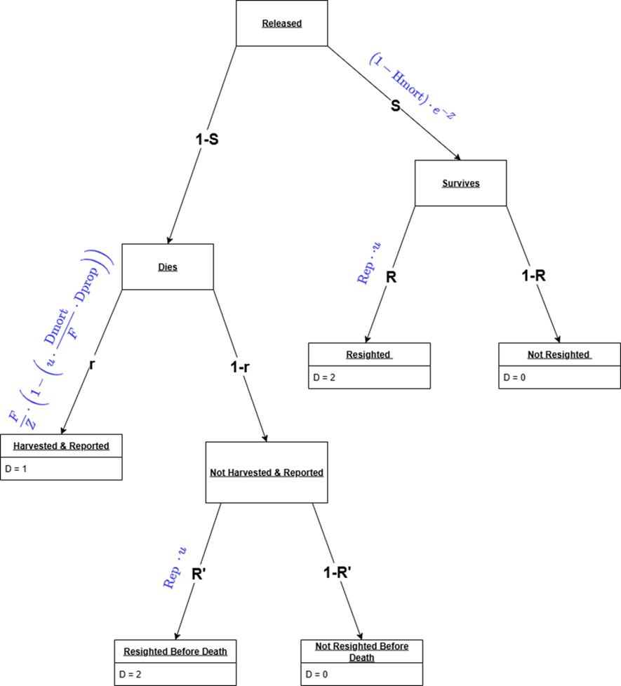

Figure S2. Fate diagram for individual based tagging model relating estimation model parameters to capture history codes and operating model parameters.

## Figure S3

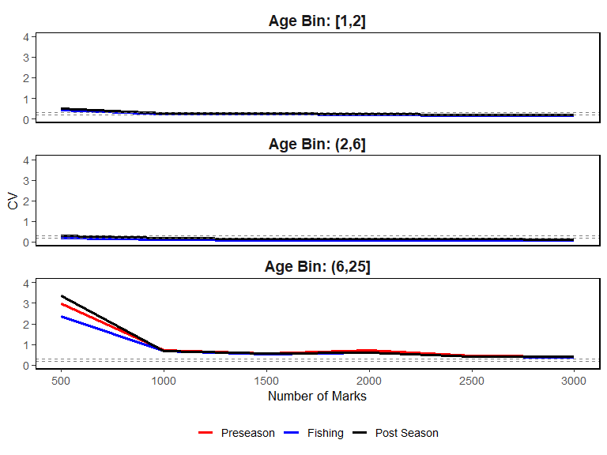

Figure S3. The estimated coefficient of variation (CV) on the catch-and-release probability parameter (R) for the conventional tagging 50% reporting scenario. The gray dashed lines represent the CVs of interest, with the top line representing a CV = 0.3 and the bottom line represents CV = 0.2.

## Figure S4

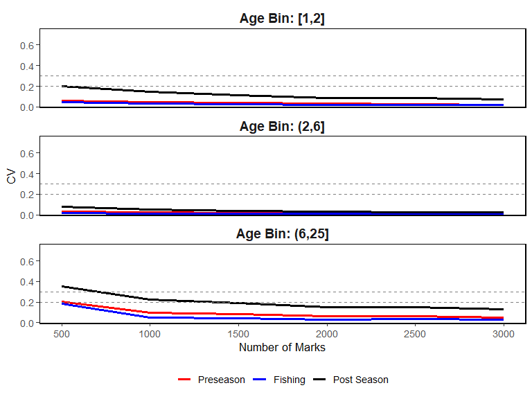

Figure S4. Estimated coefficient of variation (CV) on survival probability (S) for Atlantic red snapper estimation model scenarios across different conventional tag numbers and assuming a 95% tag reporting scenario. Grey dashed lines represent CVs of interest, with the top line indicating a CV = 0.3 and the bottom line indicating CV = 0.2.

## Figure S5

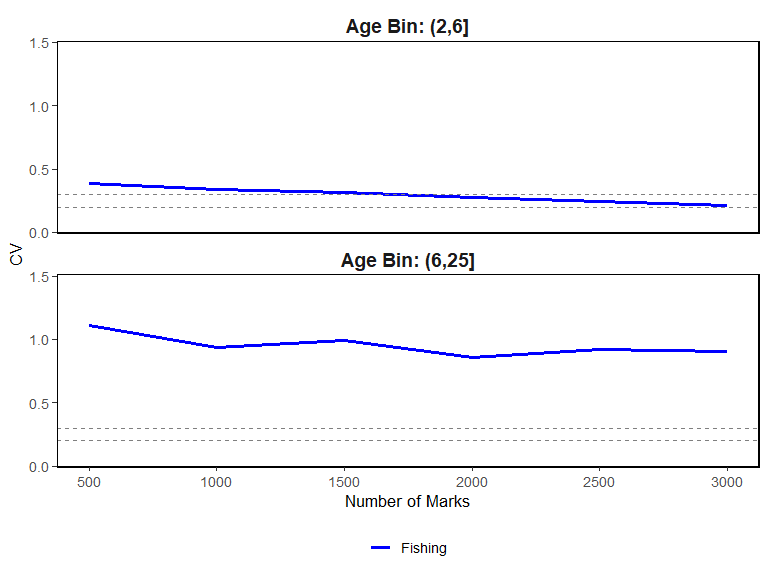

Figure S5. Estimated coefficient of variation (CV) on the dead recovery parameter (r) for Atlantic red snapper estimation model scenarios across different conventional tag numbers and assuming a 95% tag reporting rate. Grey dashed lines represent CVs of interest, with the top line indicating CV = 0.3 and the bottom line indicating CV = 0.2.

## Figure S6

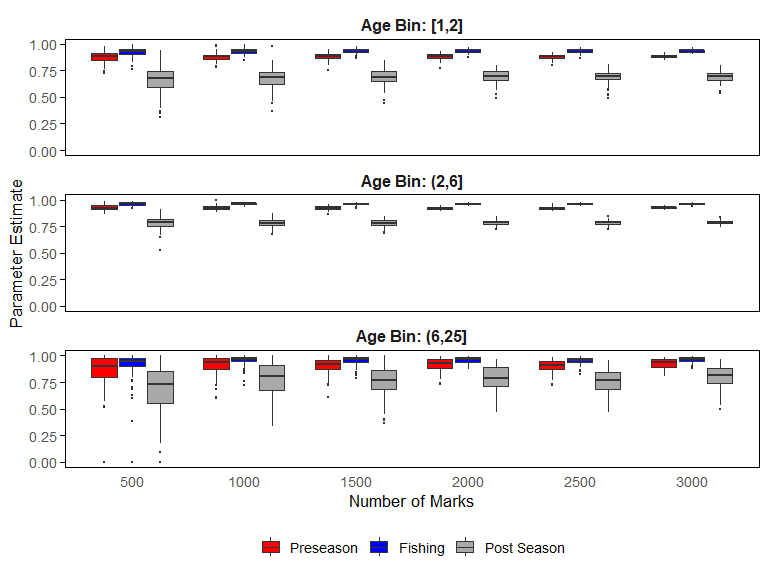

Figure S6. Boxplots by time and age bin of estimation model results for Atlantic red snapper monthly survival probability (S) estimated via simulation of conventional tagging under different tag number scenarios and assuming a 95% tag reporting rate. Survival probability is estimated under each tagging scenario and for each age bin for preseason, fishing season, and post season time periods.

## Figure S7

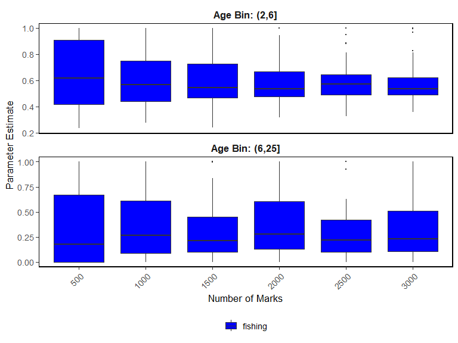